# dredge figures

## Figure S2

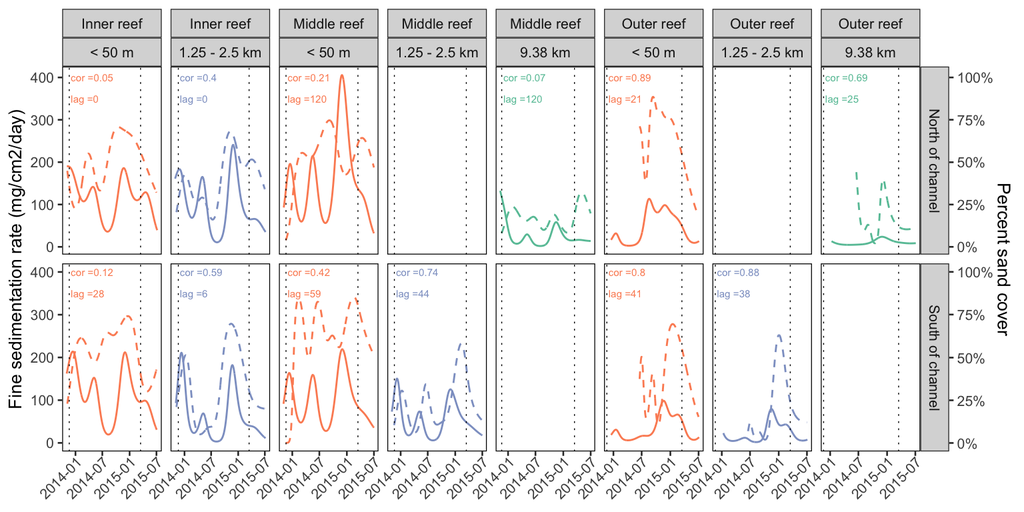

```
## [1] 0.5063022
```

```
## [1] 33
```

# Figure 4

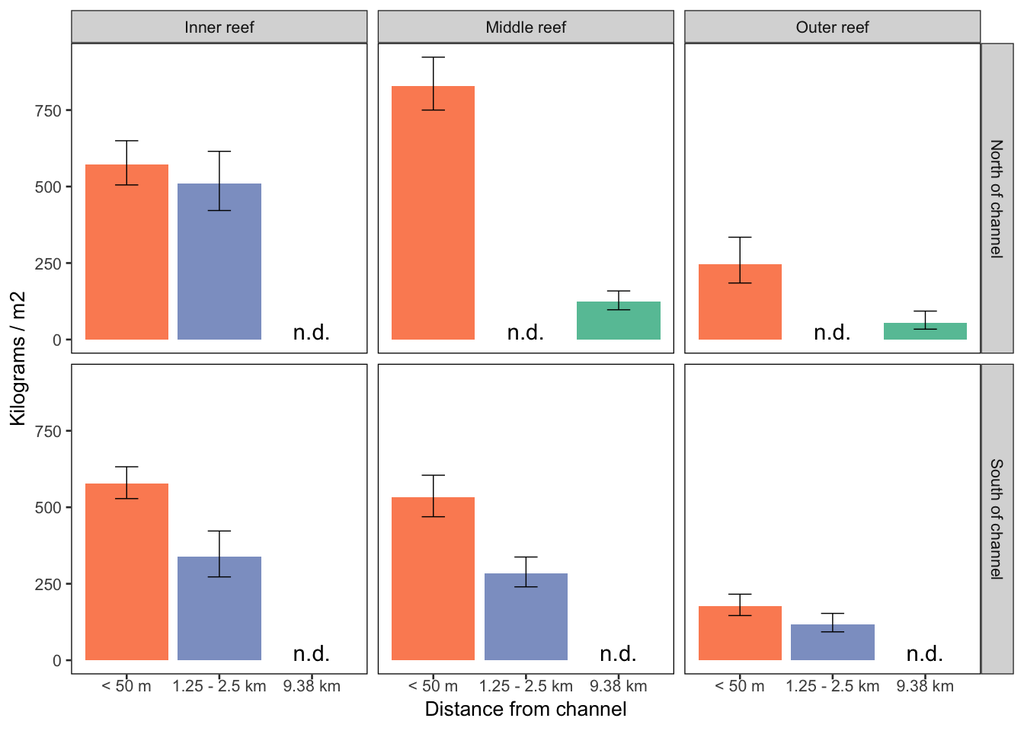

# 2. Sediments buried tagged corals

# 3. Sedimentation killed tagged corals

### 3.1 Partial mortality

This figure uses the tagged coral data to calculate the probability that corals were recorded with the “PM” condition code (=partial mortality due to sedimentation) during the dredging project.

## Figure S4

Figure S4. Coral partial mortality due to sedimentation in each monitoring area throughout dredging operations. Bars indicate the predicted probability (±95% CI) of tagged corals being observed with the condition code PM (partial mortality due to sedimentation) at any point through March 2015 (the final month of dredging operations). Bar colors correspond to distance from channel, and empty spaces indicate areas that were not monitored.

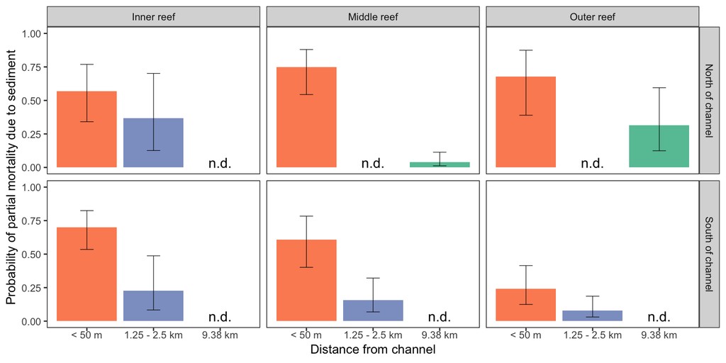

```
##        channel reef dir       prob         SE df  asymp.LCL asymp.UCL
## 1  channelside   HB   N 0.56770848 0.11657185 NA 0.34108323 0.7691444
## 2      control   HB   N 0.36813352 0.16554999 NA 0.12618235 0.7015477
## 3  channelside   R2   N 0.74711070 0.08747531 NA 0.54384235 0.8798174
## 4      control   R2   N 0.03828935 0.02201188 NA 0.01218667 0.1138572
## 5  channelside   R3   N 0.67860673 0.13312112 NA 0.38961667 0.8747555
## 6      control   R3   N 0.31350263 0.12817435 NA 0.12443796 0.5947096
## 7  channelside   HB   S 0.69940554 0.07555137 NA 0.53497575 0.8247411
## 8      control   HB   S 0.22709813 0.10522270 NA 0.08319402 0.4875478
## 9  channelside   R2   S 0.60913635 0.10235585 NA 0.40157289 0.7835173
## 10     control   R2   S 0.15754232 0.06295653 NA 0.06873209 0.3214911
## 11 channelside   R3   S 0.24088905 0.07488258 NA 0.12450700 0.4145474
## 12     control   R3   S 0.07838217 0.03643118 NA 0.03068009 0.1860191
##         dist_cat
## 1         < 50 m
## 2  1.25 - 2.5 km
## 3         < 50 m
## 4        9.38 km
## 5         < 50 m
## 6        9.38 km
## 7         < 50 m
## 8  1.25 - 2.5 km
## 9         < 50 m
## 10 1.25 - 2.5 km
## 11        < 50 m
## 12 1.25 - 2.5 km
```

### Finding: With the exception of R3S, 50-75% of all corals in channelside areas suffered partial mortality due to sedimentation.

Here we can also show the figure with partial mortality as a function of sediment deposition:

# Figure 6

```
## [1] 0.5197085
```

```
## [1] 0.5197085
```

```
## [1] 0.8817407
```

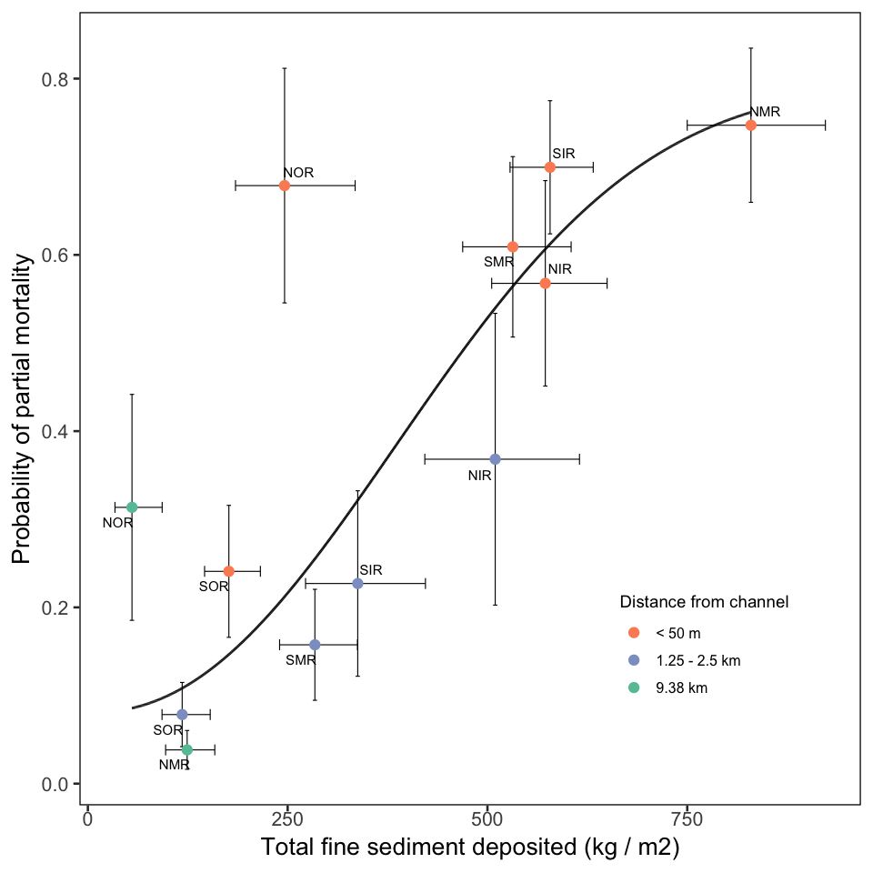

### 3.2 Total mortality

To test whether sedimentation caused total mortality of corals, we can look at disease-resistant species because death cannot be attributed to disease. However, using only this subset of tagged corals limits the power of the analysis, and a significant difference between channelside and control sites is only seen at the northern middle reef. However, this is where impacts are the greatest based on other metrics. The estimated probability of total mortality at the northern middle reef channelside sites is greater than 50%

## Figure S5

```
##        channel reef dir         prob           SE df    asymp.LCL
## 1  channelside   HB   N 4.076648e-01 2.362299e-01 NA 9.186898e-02
## 2      control   HB   N 3.298472e-09 6.037008e-05 NA 2.220446e-16
## 3  channelside   R2   N 5.698966e-01 2.364957e-01 NA 1.666417e-01
## 4      control   R2   N 1.285493e-01 1.220263e-01 NA 1.714420e-02
## 5  channelside   R3   N 1.896895e-01 1.769991e-01 NA 2.391620e-02
## 6      control   R3   N 4.371113e-02 6.455733e-02 NA 2.210203e-03
## 7  channelside   HB   S 7.608389e-10 4.190032e-06 NA 2.220446e-16
## 8      control   HB   S 2.287900e-02 3.619367e-02 NA 9.794145e-04
## 9  channelside   R2   S 5.026909e-02 7.390404e-02 NA 2.540674e-03
## 10     control   R2   S 2.409331e-01 1.813767e-01 NA 4.346435e-02
## 11 channelside   R3   S 6.995384e-02 7.576243e-02 NA 7.616687e-03
## 12     control   R3   S 1.180761e-01 9.741433e-02 NA 2.095373e-02
##    asymp.UCL      dist_cat
## 1  0.8240121        < 50 m
## 2  1.0000000 1.25 - 2.5 km
## 3  0.8977505        < 50 m
## 4  0.5550531       9.38 km
## 5  0.6910289        < 50 m
## 6  0.4853901       9.38 km
## 7  1.0000000        < 50 m
## 8  0.3586550 1.25 - 2.5 km
## 9  0.5237834        < 50 m
## 10 0.6891687 1.25 - 2.5 km
## 11 0.4243285        < 50 m
## 12 0.4557933 1.25 - 2.5 km
```

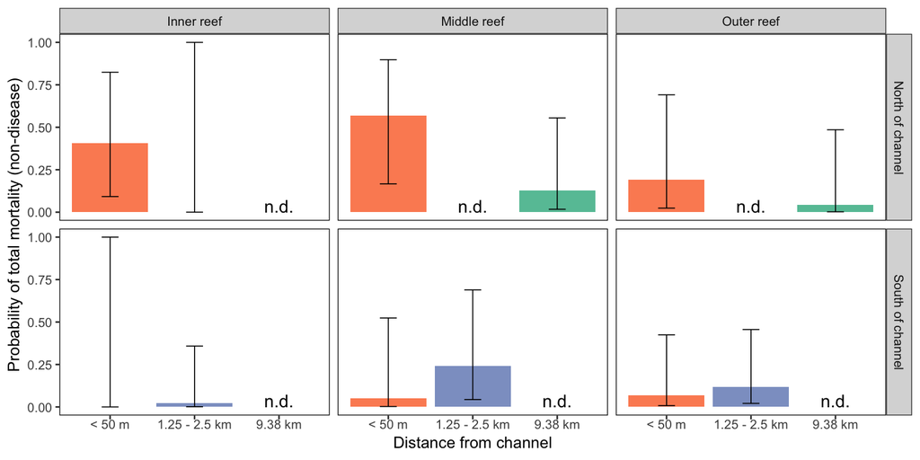

### Finding: The probability of complete mortality on the northern middle reef was estimated at over 50%.

# 4. Long-lasting impacts to ecosystem

## 4.1 Reduced coral density

### Corals larger than 3 cm

This figure is based on the coral count data before dredgine (2009 and 2013) and after dredging (2015 and 2016/2017). Coral density significantly declines after dredging nearer to the channel, but this effect diminishes further from the channel, suggesting it is directly related to dredging activity. Disease may have also led to declines in coral density regionally, but this effect would not be expected to show any relationship to the channel.

## Figure 7

Figure 7. Density of corals ≥3cm within 500m from the channel in each monitoring region before and after dredging operations. Data ‘before’ dredging were collected in 2009 and 2013, and data after dredging were collected in 2015-2017. GLMM fits are shown as lines for the regions and times in which data were collected at >2 points beyond 50m, and otherwise as points including only data from within 50m of the channel. Shaded regions and error bars represent 84% CI’s. Text annotations indicate the results of tests for differences between timepoints at 20m and 300m from the channel (*** = p < 0.0001; ns = not significantly different).

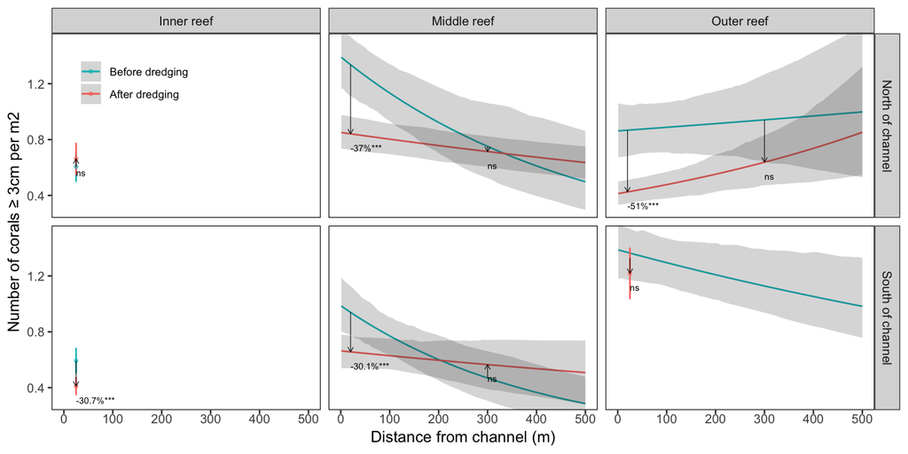

```
## # A tibble: 3 x 4
## # Groups:   reef [?]
##   reef  dir   thresh_dist total_diff
##   <chr> <chr>       <dbl>      <dbl>
## 1 R2    N             334      -77.8
## 2 R2    S             204      -29.7
## 3 R3    N             500     -161.
```

```
## [1] 91350
```

### Corals smaller than 3 cm

Here we use coral count data only from transects in 2009 and 2016/2017 when small corals were counted, in areas within 100m of the reef channel (this distance can be adjusted up to 500m threshold (data only collected within 500m in 2009) and the result does not change).

## Figure S6

Figures S6. Density of small corals (1-2cm) within 500m from the channel in each monitoring region before and after dredging operations. Data ‘before’ dredging were collected in 2009, and data after dredging were collected in 2016-2017. GLMM fits are shown as lines for the regions and times in which data were collected at >2 points beyond 50m. Shaded regions and error bars represent 84% CI’s. Text annotations indicate the results of tests for differences between timepoints at 20m and 300m from the channel (. = p < 0.1; * = p < 0.05; ns = not significantly different).

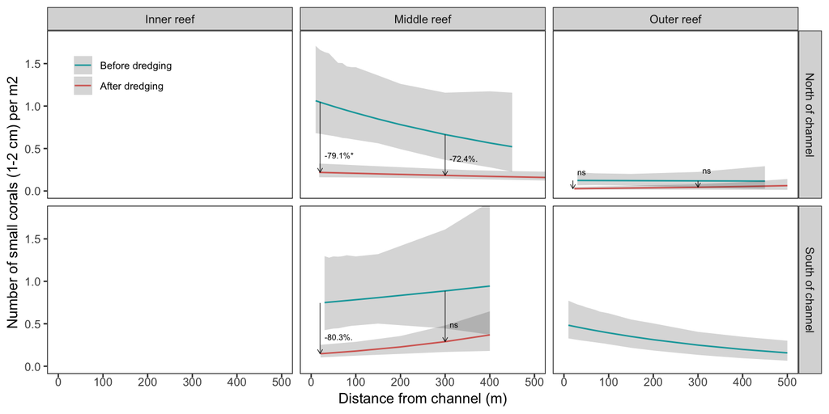

### Size frequency distributions also show loss of small corals

A Kruskal-Wallis non-parametric test for difference in mean diameter shows that average coral size was significantly larger after dredging than before at all sites except R3N, suggesting that smaller corals were disproportionaly removed from the population due to burial, and/or that dredging sedimentation prevented coral recruitment.

## Figure 8

Figure 8. Size frequency distribution of corals before and after dredging. For the northern and southern middle and outer reefs, histograms show the relative proportion of corals within 100m of the channel with a given maximum diameter. P-values on each panel are based on a Kruskal-Wallis test for a difference in mean diameter between the two timepoints.

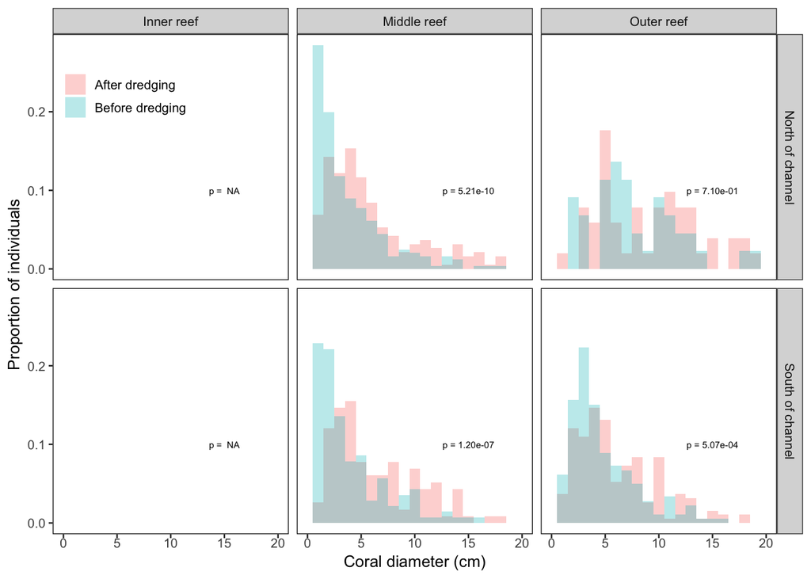

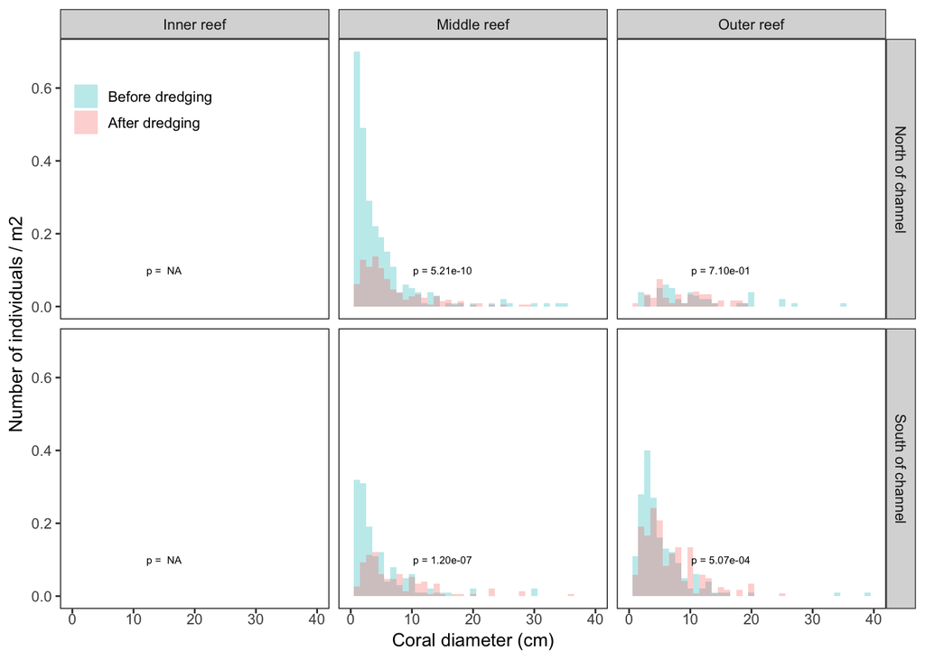

## 4.2 Elevated sand cover

## Figure 9

Figure 9. Depth of sediments in relation to channel measured ~2 years after dredging operations. Dots represent individual sediment depth measurements along transects, jittered around the distance from the center of the transect to the channel in each monitoring region (no data available for the inner reef). Lines represent quantile regressions across transects as a function of log(distance from channel), e.g., the percent of reef area with sediments measuring at least a given depth.

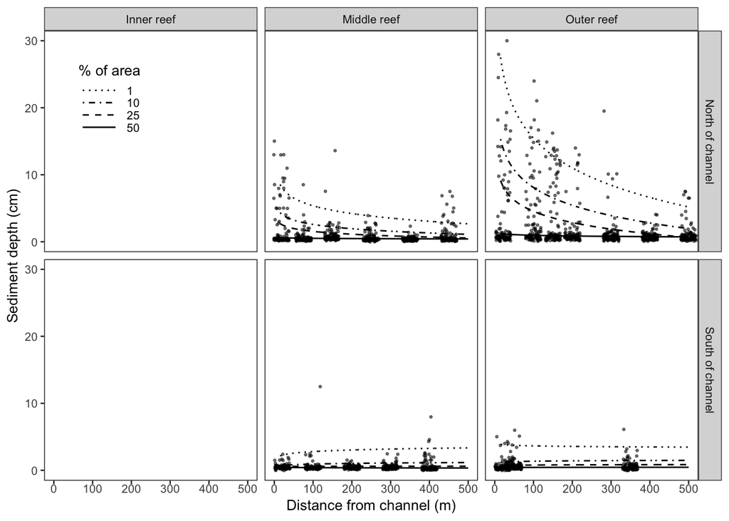

### Finding: Significant area north of the channel under deep sediments 2 years later. One quarter of the northern outer reef near the channel is under 10+ cm of sediments, and there are pockets (~1%) up to 30cm deep. One quarter of the northern middle reef is under 3+ cm, with pockets of 10+ cm.

# Before vs. after sand cover

## Figure S7

Figure S7. Percent cover before (2013) and after dredging (2016) at the three permanent monitoring sites for which both before and after data were collected. Bars indicate the mean percent sand based on CPCe analysis, and error bars represent standard deviation.

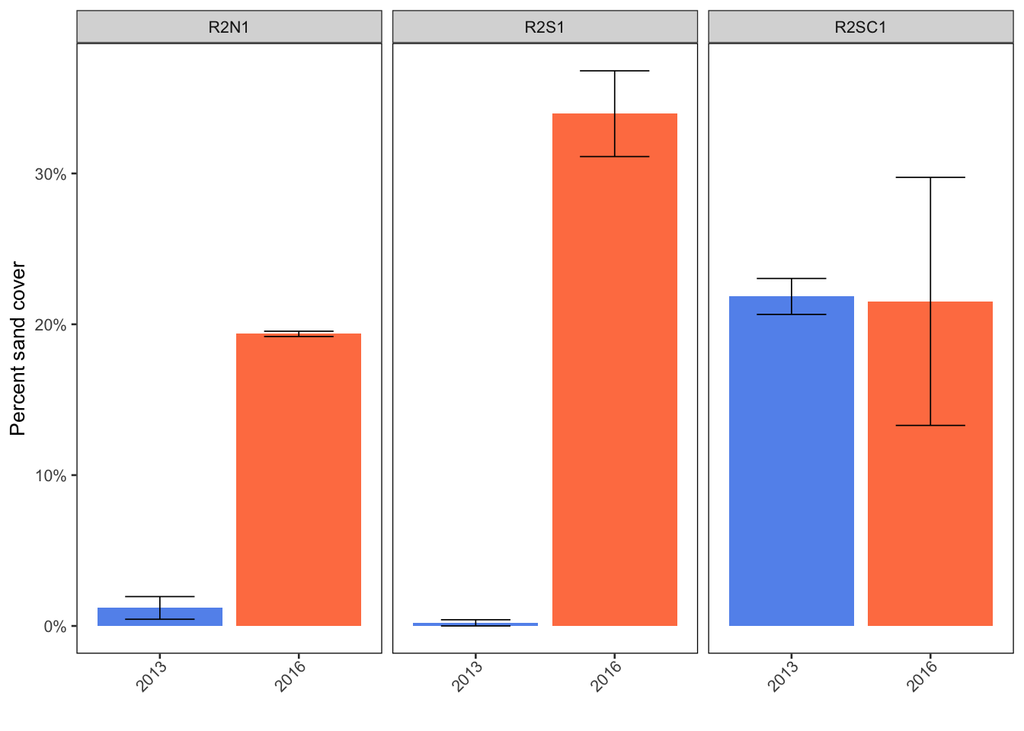